The point of this is to bring home to you the worthlessness of polynomial regression when you have splines that are easily programmed.

### 1. Read fossil data

```r
setwd("~/tamu/MS-STAT-2022/689-flexible-regression")
fossil = read.csv("fossil.csv")
head(fossil)
```

```
##         Age Strontium.Ratio
## 1  91.78525        0.707343
## 2  92.39579        0.707359
## 3  93.97061        0.707410
## 4  95.57577        0.707438
## 5  95.60286        0.707463
## 6 112.33691        0.707320
```

### 2. Do a scatterplot of the data, with X = age. As seen near the end of Lecture 1, it is distinctly not linear, and hence a perfect example for semiparametric regression.

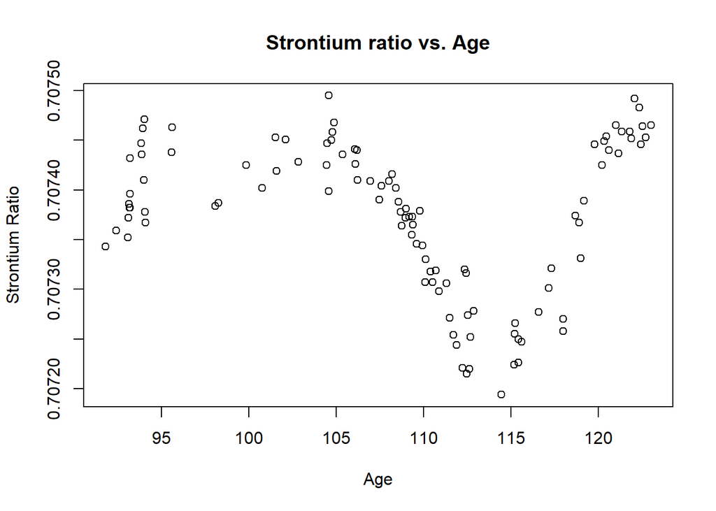

```r
plot(fossil$Age, fossil$Strontium.Ratio
     , main="Strontium ratio vs. Age"
     , xlab="Age"
     , ylab="Strontium Ratio")
```

### 3. Fit a linear model and add the fit to the scatterplot

```r
lin_mod = lm(Strontium.Ratio ~ Age, data = fossil)
summary(lin_mod)
```

```
##
## Call:
## lm(formula = Strontium.Ratio ~ Age, data = fossil)
##
## Residuals:
##        Min         1Q     Median         3Q        Max
## -1.720e-04 -5.277e-05  6.711e-06  6.278e-05  1.369e-04
##
## Coefficients:
##               Estimate Std. Error  t value Pr(>|t|)
## (Intercept)  7.075e-01  8.807e-05 8033.736   <2e-16 ***
## Age         -1.430e-06  8.068e-07   -1.772   0.0793 .
## ---
## Signif. codes:  0 '***' 0.001 '**' 0.01 '*' 0.05 '.' 0.1 ' ' 1
##
## Residual standard error: 7.529e-05 on 104 degrees of freedom
## Multiple R-squared:  0.02932,    Adjusted R-squared:  0.01999
## F-statistic: 3.141 on 1 and 104 DF,  p-value: 0.07926
```

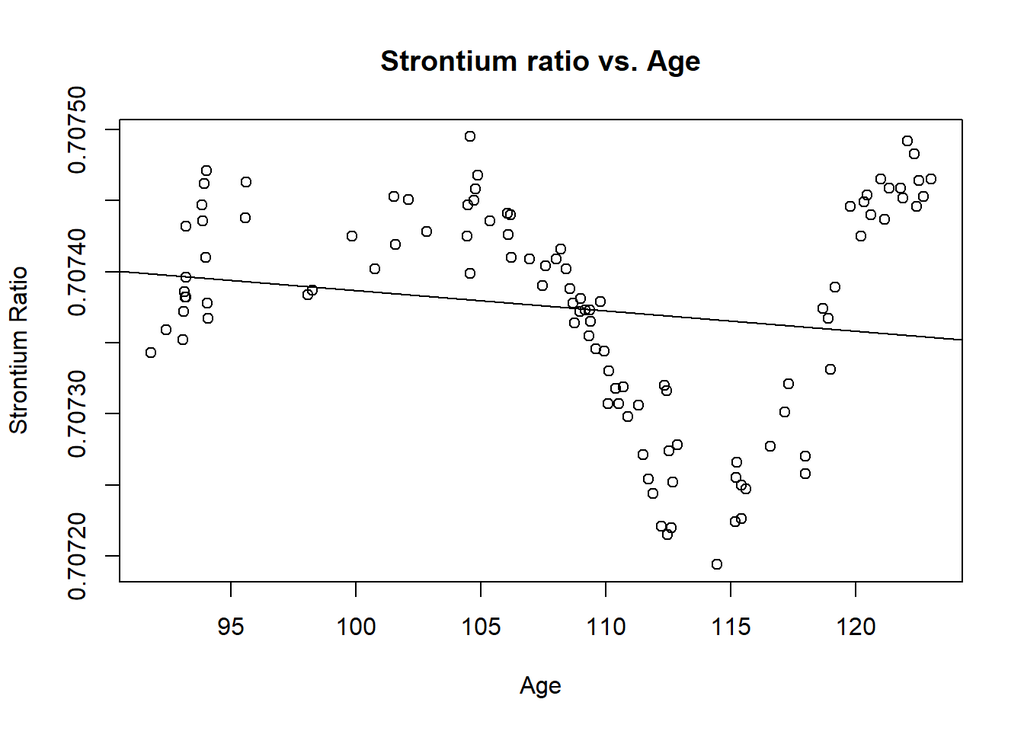

```r
plot(fossil$Age, fossil$Strontium.Ratio
     , main="Strontium ratio vs. Age"
     , xlab="Age"
     , ylab="Strontium Ratio")
abline(lin_mod)
```

This model does not fit well as can be seen in the above graph. Age is not statistically significant at 0.05.

### 4. Fit a quadratic model and add the fit to the scatterplot of the raw data. Does this help? Why or why not?

```r
quad_mod <- lm(Strontium.Ratio ~ Age + I(Age^2)
               ,data=fossil)
summary(quad_mod)
```

```
##
## Call:
## lm(formula = Strontium.Ratio ~ Age + I(Age^2), data = fossil)
##
## Residuals:
##        Min         1Q     Median         3Q        Max
## -1.618e-04 -4.976e-05  1.566e-05  5.759e-05  1.384e-04
##
## Coefficients:
##               Estimate Std. Error t value Pr(>|t|)
## (Intercept)  7.110e-01  9.469e-04 750.885  < 2e-16 ***
## Age         -6.723e-05  1.773e-05  -3.792 0.000252 ***
## I(Age^2)     3.067e-07  8.254e-08   3.715 0.000330 ***
## ---
## Signif. codes:  0 '***' 0.001 '**' 0.01 '*' 0.05 '.' 0.1 ' ' 1
##
## Residual standard error: 7.104e-05 on 103 degrees of freedom
## Multiple R-squared:  0.144,  Adjusted R-squared:  0.1274
## F-statistic: 8.665 on 2 and 103 DF,  p-value: 0.0003326
```

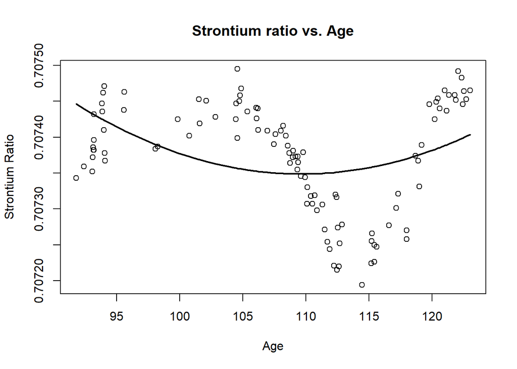

```r
plot(fossil$Age, fossil$Strontium.Ratio
     , main="Strontium ratio vs. Age"
     , xlab="Age"
     , ylab="Strontium Ratio")
#use model to get predicted values
pred <- predict(quad_mod)
ix <- sort(fossil$Age, index.return=T)$ix

#add polynomial curve to plot
lines(fossil$Age[ix], pred[ix],lwd=2)
```

All coefficients are statistically significant at 0.05 but the fitted line is not flexible enough to fit the data as can be seen in the above graph. This is not a good fit.

### 5. Fit a cubic model and add the fit to the scatterplot of the raw data. Does this help? Why or why not?

```r
cubic_mod <- lm(Strontium.Ratio ~ Age + I(Age^2) + I(Age^3)
               ,data=fossil)
summary(cubic_mod)
```

```
##
## Call:
## lm(formula = Strontium.Ratio ~ Age + I(Age^2) + I(Age^3), data = fossil)
##
## Residuals:
##        Min         1Q     Median         3Q        Max
## -1.018e-04 -2.845e-05  5.800e-06  2.952e-05  7.984e-05
##
## Coefficients:
##               Estimate Std. Error t value Pr(>|t|)
## (Intercept)  5.800e-01  9.259e-03   62.65   <2e-16 ***
## Age          3.618e-03  2.602e-04   13.91   <2e-16 ***
## I(Age^2)    -3.407e-05  2.426e-06  -14.05   <2e-16 ***
## I(Age^3)     1.064e-07  7.505e-09   14.18   <2e-16 ***
## ---
## Signif. codes:  0 '***' 0.001 '**' 0.01 '*' 0.05 '.' 0.1 ' ' 1
##
## Residual standard error: 4.142e-05 on 102 degrees of freedom
## Multiple R-squared:  0.7118, Adjusted R-squared:  0.7033
## F-statistic: 83.97 on 3 and 102 DF,  p-value: < 2.2e-16
```

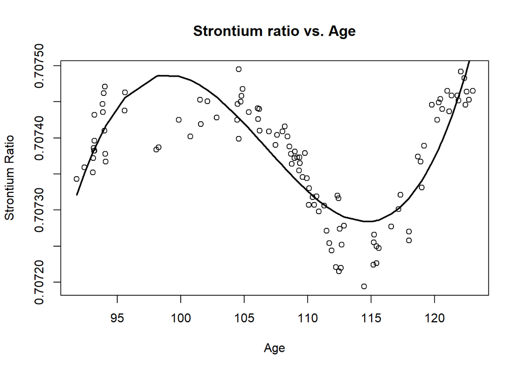

```r
plot(fossil$Age, fossil$Strontium.Ratio
     , main="Strontium ratio vs. Age"
     , xlab="Age"
     , ylab="Strontium Ratio")
#use model to get predicted values
pred <- predict(cubic_mod)
ix <- sort(fossil$Age, index.return=T)$ix

#add polynomial curve to plot
lines(fossil$Age[ix], pred[ix],lwd=2)
```

Coefficients are statistically significant and the cubic model fits much better than quadratic in the above graph, but there are still some points that it does not fit well as seen in the above graph.

### 6. Fit a quartic model and add the fit to the scatterplot of the raw data. Does this help? Why or why not?

```r
quartic_mod <- lm(Strontium.Ratio ~ Age + I(Age^2) + I(Age^3) + I(Age^4)
               ,data=fossil)
summary(quartic_mod)
```

```
##
## Call:
## lm(formula = Strontium.Ratio ~ Age + I(Age^2) + I(Age^3) + I(Age^4),
##     data = fossil)
##
## Residuals:
##        Min         1Q     Median         3Q        Max
## -8.381e-05 -2.518e-05  2.624e-06  2.799e-05  9.119e-05
##
## Coefficients:
##               Estimate Std. Error t value Pr(>|t|)
## (Intercept)  9.198e-01  1.280e-01   7.186 1.17e-10 ***
## Age         -9.092e-03  4.783e-03  -1.901  0.06018 .
## I(Age^2)     1.437e-04  6.684e-05   2.150  0.03398 *
## I(Age^3)    -9.950e-07  4.140e-07  -2.404  0.01806 *
## I(Age^4)     2.551e-09  9.588e-10   2.661  0.00907 **
## ---
## Signif. codes:  0 '***' 0.001 '**' 0.01 '*' 0.05 '.' 0.1 ' ' 1
##
## Residual standard error: 4.024e-05 on 101 degrees of freedom
## Multiple R-squared:  0.7307, Adjusted R-squared:   0.72
## F-statistic:  68.5 on 4 and 101 DF,  p-value: < 2.2e-16
```

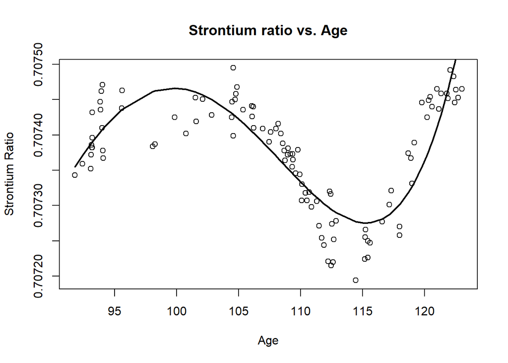

```r
plot(fossil$Age, fossil$Strontium.Ratio
     , main="Strontium ratio vs. Age"
     , xlab="Age"
     , ylab="Strontium Ratio")
#use model to get predicted values
pred <- predict(quartic_mod)
#get sorted indices
ix <- sort(fossil$Age, index.return=T)$ix

#add polynomial curve to plot
lines(fossil$Age[ix], pred[ix],lwd=2)
```

This looks better than quadratic and linear but looks similar to the cubic model in terms of fit. In other words, quartic does not lead to much improvement over cubic. Quartic model gets us more complexity but less significance compared to the cubic model as per the model summary output.